# Part1

## IODS-final

Background

Alcohol use continues to be prevalent among youth. To implement preventive measures the sociodemographic, individual and parental factors behind problem behavior should be understood better.

Objective

To investigate the association between high alcohol consumption and sociodemographic factors.

Method

Results

Conclusion

### Introduction

Data including grades, demographic, social and school related features were collected in two Portuguese schools using school reports and questionnaires and stored as two separate datasets regarding performance in distinct subjects, namely Mathematics and Portuguese.

The original data of the analysis in this exercise are freely available as a [zip file](https://archive.ics.uci.edu/ml/machine-learning-databases/00320/). Additional [metadata](https://archive.ics.uci.edu/ml/datasets/Student+Performance) information describes basic characteristics of the data sets. For the purpose of this particular exercise they needed to be joined and edited according to [this R script](https://github.com/paap0/IODS-project/blob/master/data/create_alc.R).

A link to your data wrangling script. See the general instructions. (max 5 points)

The variables not used for joining the two data sets were combined by averaging them. An additional variable *high_use* was created by taking the average of the sum of alcohol consumption during weekdays and weekends, which was thereafter further modified to yield a logical TRUE or FALSE *high_use* variable. A treshold value for higher than average alcohol consumption was chosen to be more than 2 weekly proportions.

Variable labels and their explanations are described below:

```r
dfalc<-read.csv(file="alccatfin.csv",header=TRUE)
dfalc<-mutate_all(dfalc,as.factor)
dfalc$Final_Grade<-as.numeric(dfalc$Final_Grade)

Label<-as.matrix(colnames(dfalc))

Variable<-c("Gender", "Age categorized",  "Parent's cohabitation status","Mother´s educational status categorized (less than secondary education, secondary education, higher education", "Father´s educational status categorized (less than secondary education, secondary education, higher education", "Mother´s job (teacher, health care, civil services, at home, other)", "Father´s job (teacher, health care, civil services, at home, other)", "Student´s guardian: mother, father, other", "Family educational support", "Willingness to take higher education", "Relationship", "Extra-cullicular activities", "Familial relationships categorized (very bad to bad, average, good to excellent)","Going out with friends categorized (very low or low, average, high or very high)","Health status categorized (very bad to bad, average, good to very good)", "Amount of failed classes: none/more than one)", "Amount of school absences one or less, 2-6hours, more than 6 hours", "Final grade categorized by quartiles", "Final grade", "Alcohol consumption more than two either during the week or at weekends")

Level<-as.matrix(dfalc %>% sapply(levels))

om<- data.frame(Label,Variable,Level)

om$Level[3]<-"A(Alone),T(Together)"
om$Level[19]<-"numeric from 0 to 20"
rownames(om)<-NULL
kable(om, title="Basic elements of the dataset","html") %>%
  kable_styling(bootstrap_options = "striped", full_width = F)
```

| Label | Variable | Level |
| --- | --- | --- |
| Gender | Gender | F, M |
| Agegroup | Age categorized | (0,16], (16,17], (17,Inf] |
| Parents.together | Parent’s cohabitation status | A(Alone),T(Together) |
| Education_M | Mother´s educational status categorized (less than secondary education, secondary education, higher education | (-1,2], (2,3], (3,4] |
| Education_F | Father´s educational status categorized (less than secondary education, secondary education, higher education | (-1,2], (2,3], (3,4] |
| Job_M | Mother´s job (teacher, health care, civil services, at home, other) | at_home, health, other, services, teacher |
| Job_F | Father´s job (teacher, health care, civil services, at home, other) | at_home, health, other, services, teacher |
| Guardian | Student´s guardian: mother, father, other | father, mother, other |
| Familial_support | Family educational support | no, yes |
| Education_pos | Willingness to take higher education | no, yes |
| In_relationship | Relationship | no, yes |
| Activities | Extra-cullicular activities | no, yes |
| Family_relationships | Familial relationships categorized (very bad to bad, average, good to excellent) | (0,2], (2,3], (3,5] |
| Going_out | Going out with friends categorized (very low or low, average, high or very high) | (0,2], (2,3], (3,5] |
| Healthgroup | Health status categorized (very bad to bad, average, good to very good) | (0,2], (2,3], (3,5] |
| Class_failures | Amount of failed classes: none/more than one) | 0, 1 |
| Absencegroup | Amount of school absences one or less, 2-6hours, more than 6 hours | (-Inf,1], (1,6], (6, Inf] |
| Performancegroup | Final grade categorized by quartiles | (-Inf,10], (10,12], (12,14], (14, Inf] |
| Final_Grade | Final grade | numeric from 0 to 20 |
| High_alcohol | Alcohol consumption more than two either during the week or at weekends | 0, 1 |

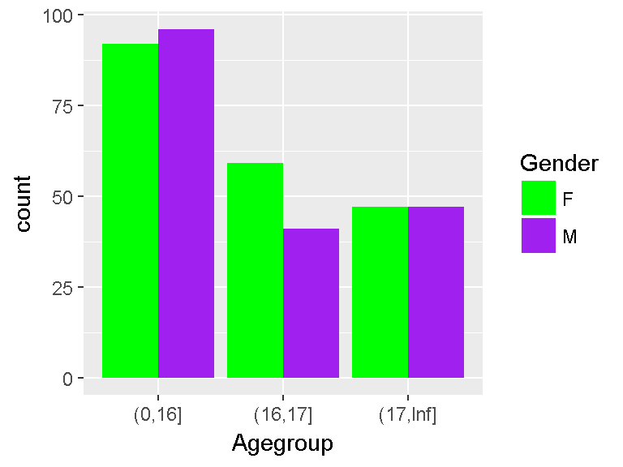

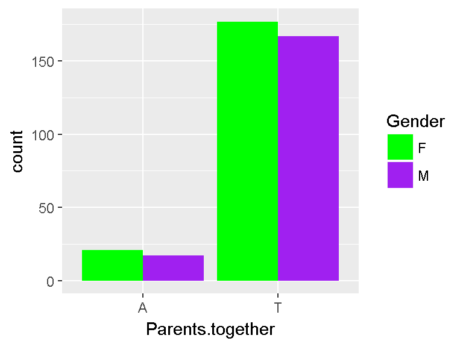

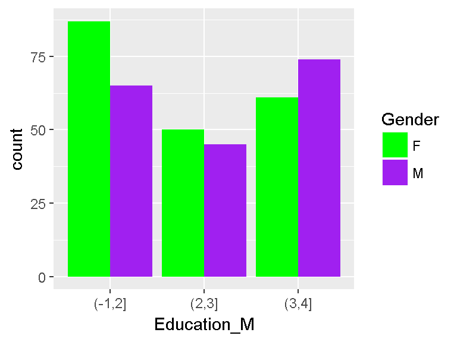

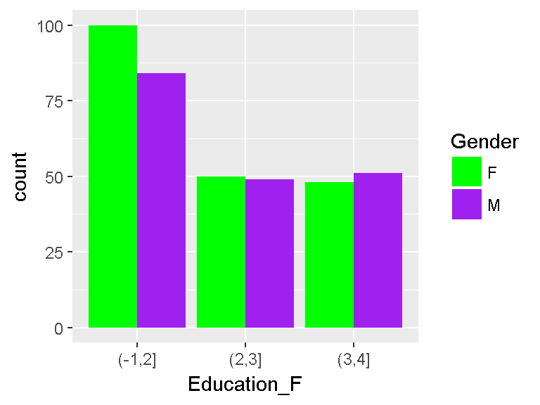

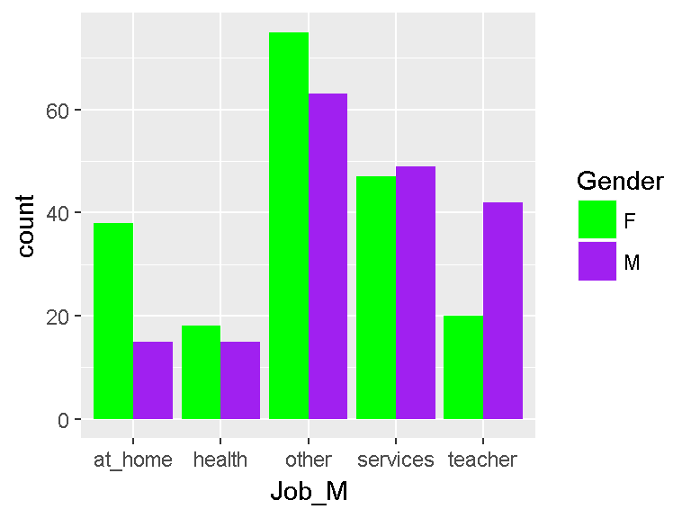

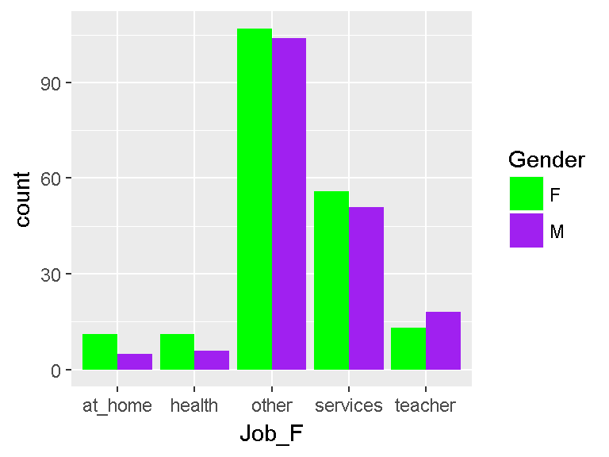

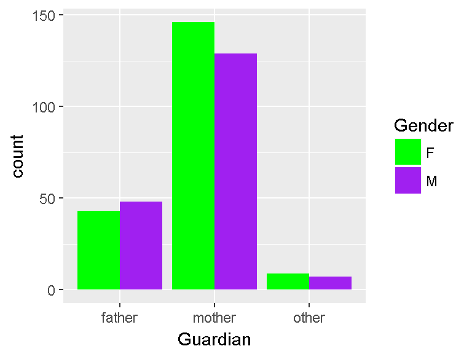

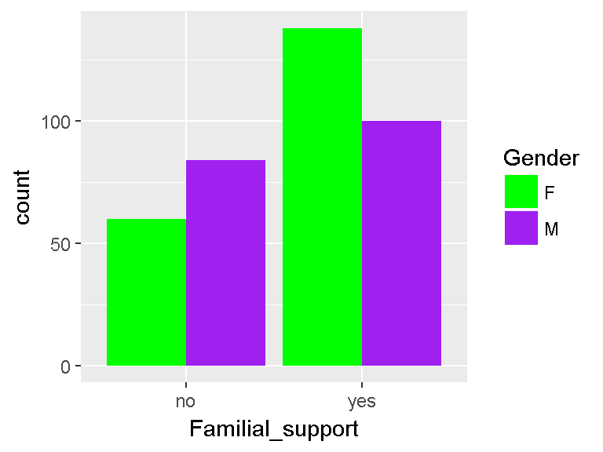

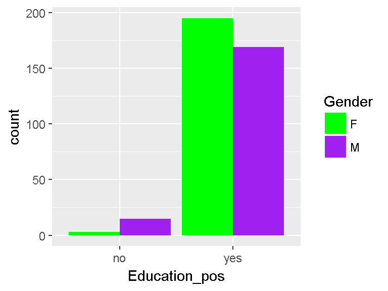

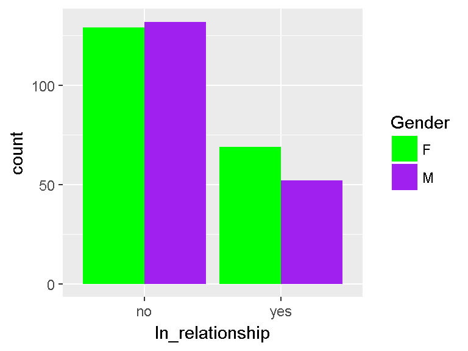

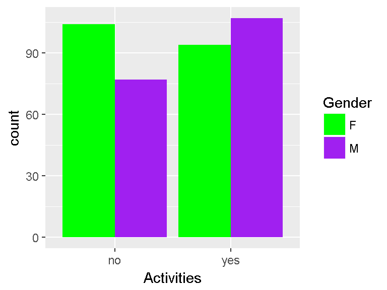

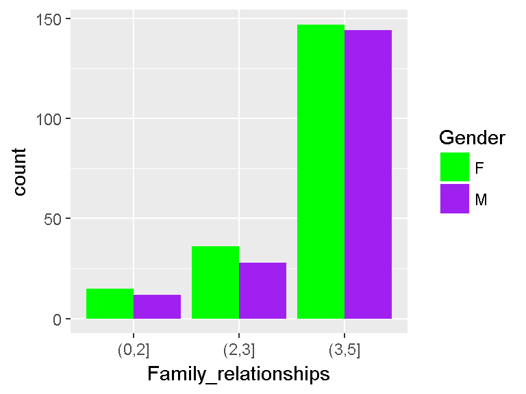

[7 more figures not shown]

```r
#lets plot
#density plots for numerical variables7
colNames <- names(dfalc)[2:ncol(dfalc)]
for(i in colNames){
    plt<-ggplot(dfalc, aes_string(x=i)) +
      geom_bar(aes(fill = Gender), position = "dodge", stat="count")+
      scale_fill_manual(values = c("green","purple"))
      print(plt)
}
```

The goal is to discover interesting relations among the variables.

## Link to my data wrangling script

Description of your data and its variables. Where is the data from, what does it relate to, what do the variables represent, what has been done to the data before analysis? (max 2 points)

Visually clear and interesting explorations of the variables of interest in the data, from the point of view of your research question. Include interpretations of the distributions and relationships of the variables. Use captions to draw the reader’s focus on the interesting parts of your tables and graphics. (max 8 points)

The variables are visualized firstly by barplots stratified by gender. Thereafter, one crude variable summary as well as summary tables are created using three different strata: gender, performance group and alcohol use. ###

Brief description of the method(s) you are using in your own words (max 3 points)

Presentation of the results of your analysis including visualizations and summaries and a thorough interpretation of the results including a validation analysis of the method. (max 16 points)

Conclusions and discussion (max 2 points)

An ‘abstract’ at the beginning of the page with a summary of your analysis (max 2 points)

Brief description of the “research question” you are exploring, possibly including your hypothesis (max 2 points)

A link to your data wrangling script. See the general instructions. (max 5 points)

Description of your data and its variables. Where is the data from, what does it relate to, what do the variables represent, what has been done to the data before analysis? (max 2 points)

Visually clear and interesting explorations of the variables of interest in the data, from the point of view of your research question. Include interpretations of the distributions and relationships of the variables. Use captions to draw the reader’s focus on the interesting parts of your tables and graphics. (max 8 points)

Presentation of the results of your analysis including visualizations and summaries and a thorough interpretation of the results including a validation analysis of the method. (max 16 points)

Conclusions and discussion (max 2 points)

An ‘abstract’ at the beginning of the page with a summary of your analysis (max 2 points)

#### Overall summary

```r
library(settings)
reset(options)
options("scipen"=10, "digits"=2)
tab1<-CreateTableOne(vars=colnames(dfalc) ,data=dfalc,factorVars = colnames(dfalc[-19]))
summary(tab1)
```

```
##
##      ### Summary of continuous variables ###
##
## strata: Overall
##               n miss p.miss mean sd median p25 p75 min max skew kurt
## Final_Grade 382    0      0   11  3     12  10  14   1  18 -0.4 0.05
##
## =======================================================================================
##
##      ### Summary of categorical variables ###
##
## strata: Overall
##                   var   n miss p.miss     level freq percent cum.percent
##                Gender 382    0    0.0         F  198    51.8        51.8
##                                               M  184    48.2       100.0
##
##              Agegroup 382    0    0.0    (0,16]  188    49.2        49.2
##                                         (16,17]  100    26.2        75.4
##                                        (17,Inf]   94    24.6       100.0
##
##      Parents.together 382    0    0.0         A   38     9.9         9.9
##                                               T  344    90.1       100.0
##
##           Education_M 382    0    0.0    (-1,2]  152    39.8        39.8
##                                           (2,3]   95    24.9        64.7
##                                           (3,4]  135    35.3       100.0
##
##           Education_F 382    0    0.0    (-1,2]  184    48.2        48.2
##                                           (2,3]   99    25.9        74.1
##                                           (3,4]   99    25.9       100.0
##
##                 Job_M 382    0    0.0   at_home   53    13.9        13.9
##                                          health   33     8.6        22.5
##                                           other  138    36.1        58.6
##                                        services   96    25.1        83.8
##                                         teacher   62    16.2       100.0
##
##                 Job_F 382    0    0.0   at_home   16     4.2         4.2
##                                          health   17     4.5         8.6
##                                           other  211    55.2        63.9
```

[output cut: 31 more lines]

```
##        Class_failures 382    0    0.0         0  334    87.4        87.4
##                                               1   48    12.6       100.0
##
##          Absencegroup 382    0    0.0  (-Inf,1]  116    30.4        30.4
##                                           (1,6]  178    46.6        77.0
##                                        (6, Inf]   88    23.0       100.0
##
##      Performancegroup 382    0    0.0 (-Inf,10]  143    37.4        37.4
##                                         (10,12]  107    28.0        65.4
##                                         (12,14]   64    16.8        82.2
##                                       (14, Inf]   68    17.8       100.0
##
##          High_alcohol 382    0    0.0         0  228    59.7        59.7
##                                               1  154    40.3       100.0
##
```

```r
reset(options)
```

#### Summary stratified by gender

Data variable summary stratified by GENDER

|  | F | M | p | test |
| --- | --- | --- | --- | --- |
| n | 198 | 184 |  |  |
| Gender = M (%) | 0 ( 0.0) | 184 (100.0) | <0.001 |  |
| Agegroup (%) |  |  | 0.245 |  |
| (0,16] | 92 (46.5) | 96 ( 52.2) |  |  |
| (16,17] | 59 (29.8) | 41 ( 22.3) |  |  |
| (17,Inf] | 47 (23.7) | 47 ( 25.5) |  |  |
| Parents.together = T (%) | 177 (89.4) | 167 ( 90.8) | 0.783 |  |
| Education_M (%) |  |  | 0.123 |  |
| (-1,2] | 87 (43.9) | 65 ( 35.3) |  |  |
| (2,3] | 50 (25.3) | 45 ( 24.5) |  |  |
| (3,4] | 61 (30.8) | 74 ( 40.2) |  |  |
| Education_F (%) |  |  | 0.612 |  |
| (-1,2] | 100 (50.5) | 84 ( 45.7) |  |  |
| (2,3] | 50 (25.3) | 49 ( 26.6) |  |  |
| (3,4] | 48 (24.2) | 51 ( 27.7) |  |  |
| Job_M (%) |  |  | 0.001 |  |
| at_home | 38 (19.2) | 15 ( 8.2) |  |  |
| health | 18 ( 9.1) | 15 ( 8.2) |  |  |
| other | 75 (37.9) | 63 ( 34.2) |  |  |
| services | 47 (23.7) | 49 ( 26.6) |  |  |
| teacher | 20 (10.1) | 42 ( 22.8) |  |  |
| Job_F (%) |  |  | 0.367 |  |
| at_home | 11 ( 5.6) | 5 ( 2.7) |  |  |
| health | 11 ( 5.6) | 6 ( 3.3) |  |  |
| other | 107 (54.0) | 104 ( 56.5) |  |  |
| services | 56 (28.3) | 51 ( 27.7) |  |  |
| teacher | 13 ( 6.6) | 18 ( 9.8) |  |  |
| Guardian (%) |  |  | 0.587 |  |
| father | 43 (21.7) | 48 ( 26.1) |  |  |
| mother | 146 (73.7) | 129 ( 70.1) |  |  |
| other | 9 ( 4.5) | 7 ( 3.8) |  |  |
| Familial_support = yes (%) | 138 (69.7) | 100 ( 54.3) | 0.003 |  |
| Education_pos = yes (%) | 195 (98.5) | 169 ( 91.8) | 0.005 |  |
| In_relationship = yes (%) | 69 (34.8) | 52 ( 28.3) | 0.203 |  |
| Activities = yes (%) | 94 (47.5) | 107 ( 58.2) | 0.047 |  |
| Family_relationships (%) |  |  | 0.653 |  |
| (0,2] | 15 ( 7.6) | 12 ( 6.5) |  |  |
| (2,3] | 36 (18.2) | 28 ( 15.2) |  |  |
| (3,5] | 147 (74.2) | 144 ( 78.3) |  |  |
| Going_out (%) |  |  | 0.662 |  |
| (0,2] | 67 (33.8) | 55 ( 29.9) |  |  |
| (2,3] | 65 (32.8) | 61 ( 33.2) |  |  |
| (3,5] | 66 (33.3) | 68 ( 37.0) |  |  |
| Healthgroup (%) |  |  | 0.087 |  |
| (0,2] | 54 (27.3) | 36 ( 19.6) |  |  |
| (2,3] | 45 (22.7) | 36 ( 19.6) |  |  |
| (3,5] | 99 (50.0) | 112 ( 60.9) |  |  |
| Class_failures = 1 (%) | 22 (11.1) | 26 ( 14.1) | 0.462 |  |
| Absencegroup (%) |  |  | 0.716 |  |
| (-Inf,1] | 57 (28.8) | 59 ( 32.1) |  |  |
| (1,6] | 96 (48.5) | 82 ( 44.6) |  |  |
| (6, Inf] | 45 (22.7) | 43 ( 23.4) |  |  |
| Performancegroup (%) |  |  | 0.661 |  |
| (-Inf,10] | 74 (37.4) | 69 ( 37.5) |  |  |
| (10,12] | 59 (29.8) | 48 ( 26.1) |  |  |
| (12,14] | 29 (14.6) | 35 ( 19.0) |  |  |
| (14, Inf] | 36 (18.2) | 32 ( 17.4) |  |  |
| Final_Grade (mean (sd)) | 11.46 (3.18) | 11.46 (3.42) | 0.994 |  |
| High_alcohol = 1 (%) | 62 (31.3) | 92 ( 50.0) | <0.001 |  |

#### Summary stratified by final grade

Data variable summary stratified by FINAL GRADE

|  | (-Inf,10] | (10,12] | (12,14] | (14, Inf] | p | test |
| --- | --- | --- | --- | --- | --- | --- |
| n | 143 | 107 | 64 | 68 |  |  |
| Gender = M (%) | 69 ( 48.3) | 48 ( 44.9) | 35 ( 54.7) | 32 ( 47.1) | 0.661 |  |
| Agegroup (%) |  |  |  |  | 0.019 |  |
| (0,16] | 60 ( 42.0) | 54 ( 50.5) | 41 ( 64.1) | 33 ( 48.5) |  |  |
| (16,17] | 36 ( 25.2) | 30 ( 28.0) | 17 ( 26.6) | 17 ( 25.0) |  |  |
| (17,Inf] | 47 ( 32.9) | 23 ( 21.5) | 6 ( 9.4) | 18 ( 26.5) |  |  |
| Parents.together = T (%) | 131 ( 91.6) | 97 ( 90.7) | 57 ( 89.1) | 59 ( 86.8) | 0.724 |  |
| Education_M (%) |  |  |  |  | 0.001 |  |
| (-1,2] | 70 ( 49.0) | 48 ( 44.9) | 20 ( 31.2) | 14 ( 20.6) |  |  |
| (2,3] | 36 ( 25.2) | 26 ( 24.3) | 16 ( 25.0) | 17 ( 25.0) |  |  |
| (3,4] | 37 ( 25.9) | 33 ( 30.8) | 28 ( 43.8) | 37 ( 54.4) |  |  |
| Education_F (%) |  |  |  |  | 0.116 |  |
| (-1,2] | 80 ( 55.9) | 52 ( 48.6) | 27 ( 42.2) | 25 ( 36.8) |  |  |
| (2,3] | 35 ( 24.5) | 29 ( 27.1) | 16 ( 25.0) | 19 ( 27.9) |  |  |
| (3,4] | 28 ( 19.6) | 26 ( 24.3) | 21 ( 32.8) | 24 ( 35.3) |  |  |
| Job_M (%) |  |  |  |  | 0.001 |  |
| at_home | 28 ( 19.6) | 14 ( 13.1) | 5 ( 7.8) | 6 ( 8.8) |  |  |
| health | 7 ( 4.9) | 5 ( 4.7) | 13 ( 20.3) | 8 ( 11.8) |  |  |
| other | 53 ( 37.1) | 47 ( 43.9) | 21 ( 32.8) | 17 ( 25.0) |  |  |
| services | 35 ( 24.5) | 21 ( 19.6) | 18 ( 28.1) | 22 ( 32.4) |  |  |
| teacher | 20 ( 14.0) | 20 ( 18.7) | 7 ( 10.9) | 15 ( 22.1) |  |  |
| Job_F (%) |  |  |  |  | 0.079 |  |
| at_home | 6 ( 4.2) | 5 ( 4.7) | 0 ( 0.0) | 5 ( 7.4) |  |  |
| health | 6 ( 4.2) | 3 ( 2.8) | 4 ( 6.2) | 4 ( 5.9) |  |  |
| other | 79 ( 55.2) | 66 ( 61.7) | 38 ( 59.4) | 28 ( 41.2) |  |  |
| services | 43 ( 30.1) | 28 ( 26.2) | 17 ( 26.6) | 19 ( 27.9) |  |  |
| teacher | 9 ( 6.3) | 5 ( 4.7) | 5 ( 7.8) | 12 ( 17.6) |  |  |
| Guardian (%) |  |  |  |  | 0.195 |  |
| father | 34 ( 23.8) | 23 ( 21.5) | 16 ( 25.0) | 18 ( 26.5) |  |  |
| mother | 98 ( 68.5) | 81 ( 75.7) | 48 ( 75.0) | 48 ( 70.6) |  |  |
| other | 11 ( 7.7) | 3 ( 2.8) | 0 ( 0.0) | 2 ( 2.9) |  |  |
| Familial_support = yes (%) | 91 ( 63.6) | 68 ( 63.6) | 36 ( 56.2) | 43 ( 63.2) | 0.752 |  |
| Education_pos = yes (%) | 126 ( 88.1) | 106 ( 99.1) | 64 (100.0) | 68 (100.0) | <0.001 |  |
| In_relationship = yes (%) | 46 ( 32.2) | 37 ( 34.6) | 19 ( 29.7) | 19 ( 27.9) | 0.804 |  |
| Activities = yes (%) | 69 ( 48.3) | 58 ( 54.2) | 35 ( 54.7) | 39 ( 57.4) | 0.589 |  |
| Family_relationships (%) |  |  |  |  | 0.505 |  |
| (0,2] | 10 ( 7.0) | 6 ( 5.6) | 8 ( 12.5) | 3 ( 4.4) |  |  |
| (2,3] | 26 ( 18.2) | 20 ( 18.7) | 9 ( 14.1) | 9 ( 13.2) |  |  |
| (3,5] | 107 ( 74.8) | 81 ( 75.7) | 47 ( 73.4) | 56 ( 82.4) |  |  |
| Going_out (%) |  |  |  |  | 0.118 |  |
| (0,2] | 40 ( 28.0) | 36 ( 33.6) | 20 ( 31.2) | 26 ( 38.2) |  |  |
| (2,3] | 42 ( 29.4) | 32 ( 29.9) | 27 ( 42.2) | 25 ( 36.8) |  |  |
| (3,5] | 61 ( 42.7) | 39 ( 36.4) | 17 ( 26.6) | 17 ( 25.0) |  |  |
| Healthgroup (%) |  |  |  |  | 0.015 |  |
| (0,2] | 27 ( 18.9) | 22 ( 20.6) | 16 ( 25.0) | 25 ( 36.8) |  |  |
| (2,3] | 34 ( 23.8) | 28 ( 26.2) | 6 ( 9.4) | 13 ( 19.1) |  |  |
| (3,5] | 82 ( 57.3) | 57 ( 53.3) | 42 ( 65.6) | 30 ( 44.1) |  |  |
| Class_failures = 1 (%) | 39 ( 27.3) | 7 ( 6.5) | 0 ( 0.0) | 2 ( 2.9) | <0.001 |  |
| Absencegroup (%) |  |  |  |  | 0.082 |  |
| (-Inf,1] | 38 ( 26.6) | 33 ( 30.8) | 18 ( 28.1) | 27 ( 39.7) |  |  |
| (1,6] | 64 ( 44.8) | 46 ( 43.0) | 36 ( 56.2) | 32 ( 47.1) |  |  |
| (6, Inf] | 41 ( 28.7) | 28 ( 26.2) | 10 ( 15.6) | 9 ( 13.2) |  |  |
| Performancegroup (%) |  |  |  |  | <0.001 |  |
| (-Inf,10] | 143 (100.0) | 0 ( 0.0) | 0 ( 0.0) | 0 ( 0.0) |  |  |
| (10,12] | 0 ( 0.0) | 107 (100.0) | 0 ( 0.0) | 0 ( 0.0) |  |  |
| (12,14] | 0 ( 0.0) | 0 ( 0.0) | 64 (100.0) | 0 ( 0.0) |  |  |
| (14, Inf] | 0 ( 0.0) | 0 ( 0.0) | 0 ( 0.0) | 68 (100.0) |  |  |
| Final_Grade (mean (sd)) | 8.10 (2.19) | 11.76 (0.43) | 13.59 (0.50) | 16.07 (0.87) | <0.001 |  |
| High_alcohol = 1 (%) | 62 ( 43.4) | 53 ( 49.5) | 21 ( 32.8) | 18 ( 26.5) | 0.010 |  |

#### Summary stratified by alcohol consumption

Data variable summary stratified by ALCOHOL CONSUMPTION

|  | 0 | 1 | p | test |
| --- | --- | --- | --- | --- |
| n | 228 | 154 |  |  |
| Gender = M (%) | 92 (40.4) | 92 ( 59.7) | <0.001 |  |
| Agegroup (%) |  |  | 0.012 |  |
| (0,16] | 126 (55.3) | 62 ( 40.3) |  |  |
| (16,17] | 50 (21.9) | 50 ( 32.5) |  |  |
| (17,Inf] | 52 (22.8) | 42 ( 27.3) |  |  |
| Parents.together = T (%) | 203 (89.0) | 141 ( 91.6) | 0.526 |  |
| Education_M (%) |  |  | 0.102 |  |
| (-1,2] | 97 (42.5) | 55 ( 35.7) |  |  |
| (2,3] | 48 (21.1) | 47 ( 30.5) |  |  |
| (3,4] | 83 (36.4) | 52 ( 33.8) |  |  |
| Education_F (%) |  |  | 0.883 |  |
| (-1,2] | 111 (48.7) | 73 ( 47.4) |  |  |
| (2,3] | 57 (25.0) | 42 ( 27.3) |  |  |
| (3,4] | 60 (26.3) | 39 ( 25.3) |  |  |
| Job_M (%) |  |  | 0.674 |  |
| at_home | 33 (14.5) | 20 ( 13.0) |  |  |
| health | 16 ( 7.0) | 17 ( 11.0) |  |  |
| other | 86 (37.7) | 52 ( 33.8) |  |  |
| services | 56 (24.6) | 40 ( 26.0) |  |  |
| teacher | 37 (16.2) | 25 ( 16.2) |  |  |
| Job_F (%) |  |  | 0.006 |  |
| at_home | 14 ( 6.1) | 2 ( 1.3) |  |  |
| health | 13 ( 5.7) | 4 ( 2.6) |  |  |
| other | 122 (53.5) | 89 ( 57.8) |  |  |
| services | 55 (24.1) | 52 ( 33.8) |  |  |
| teacher | 24 (10.5) | 7 ( 4.5) |  |  |
| Guardian (%) |  |  | 0.661 |  |
| father | 53 (23.2) | 38 ( 24.7) |  |  |
| mother | 167 (73.2) | 108 ( 70.1) |  |  |
| other | 8 ( 3.5) | 8 ( 5.2) |  |  |
| Familial_support = yes (%) | 147 (64.5) | 91 ( 59.1) | 0.338 |  |
| Education_pos = yes (%) | 219 (96.1) | 145 ( 94.2) | 0.540 |  |
| In_relationship = yes (%) | 71 (31.1) | 50 ( 32.5) | 0.872 |  |
| Activities = yes (%) | 124 (54.4) | 77 ( 50.0) | 0.461 |  |
| Family_relationships (%) |  |  | 0.178 |  |
| (0,2] | 15 ( 6.6) | 12 ( 7.8) |  |  |
| (2,3] | 32 (14.0) | 32 ( 20.8) |  |  |
| (3,5] | 181 (79.4) | 110 ( 71.4) |  |  |
| Going_out (%) |  |  | <0.001 |  |
| (0,2] | 96 (42.1) | 26 ( 16.9) |  |  |
| (2,3] | 85 (37.3) | 41 ( 26.6) |  |  |
| (3,5] | 47 (20.6) | 87 ( 56.5) |  |  |
| Healthgroup (%) |  |  | 0.232 |  |
| (0,2] | 51 (22.4) | 39 ( 25.3) |  |  |
| (2,3] | 55 (24.1) | 26 ( 16.9) |  |  |
| (3,5] | 122 (53.5) | 89 ( 57.8) |  |  |
| Class_failures = 1 (%) | 21 ( 9.2) | 27 ( 17.5) | 0.024 |  |
| Absencegroup (%) |  |  | <0.001 |  |
| (-Inf,1] | 77 (33.8) | 39 ( 25.3) |  |  |
| (1,6] | 115 (50.4) | 63 ( 40.9) |  |  |
| (6, Inf] | 36 (15.8) | 52 ( 33.8) |  |  |
| Performancegroup (%) |  |  | 0.010 |  |
| (-Inf,10] | 81 (35.5) | 62 ( 40.3) |  |  |
| (10,12] | 54 (23.7) | 53 ( 34.4) |  |  |
| (12,14] | 43 (18.9) | 21 ( 13.6) |  |  |
| (14, Inf] | 50 (21.9) | 18 ( 11.7) |  |  |
| Final_Grade (mean (sd)) | 11.74 (3.43) | 11.06 (3.04) | 0.048 |  |
| High_alcohol = 1 (%) | 0 ( 0.0) | 154 (100.0) | <0.001 |  |

### Methodology

Simple form of analysing categorical data is cross-tabulation. Correspondence analysis is also a multivariate descriptive data analytic technique and can be used in dimensionality reducation. Furthermore, the graphical interpretation of the data could be useful tool in an exploratory research and the reduction of the level of the associations between the investigated parameters. Correspondence analysis is a generalization of principal component approach for normal and contingency table data.

Multiple correspondence analysis (MCA) is an extension of correspondence analysis and allows to investigate the pattern of relationships of several categorical dependent variables. Applying multiple correspondence analysis helps to reduce the interaction parameters. Using the results of a MCA, it is possible to describe the structure of all the categorical variables included. The computational graphical representations covers basically every bit of information in the data by mapping each variable/individual of analysis as a point in a low-dimensional space.

To encompass, MCA has several features that distinguish it from other techniques of data analysis. It simplifies large and complex data and provides a detailed description of practically every bit of information in the data, yielding a simple, yet exhaustive scrutiny of relationships occuring by multiple pair wise comparisons. Graphically, dual displays are produced to facilitate interpretation.

Basically, the first step is that a crosstabulated frequency table is standardized to yield relative frequencies across the cells to sum up to 1.0. The aim of a MCA analysis is to represent the entries in the table of relative frequencies in terms of the distances between individual rows and/or columns in a low-dimensional space.

```r
library(settings)
reset(options)
options("scipen"=10, "digits"=2)
tab1<-CreateTableOne(vars=colnames(dfalc) ,data=dfalc,factorVars = colnames(dfalc[-19]))
summary(tab1)
```

```
##
##      ### Summary of continuous variables ###
##
## strata: Overall
##               n miss p.miss mean sd median p25 p75 min max skew kurt
## Final_Grade 382    0      0   11  3     12  10  14   1  18 -0.4 0.05
##
## =======================================================================================
##
##      ### Summary of categorical variables ###
##
## strata: Overall
##                   var   n miss p.miss     level freq percent cum.percent
##                Gender 382    0    0.0         F  198    51.8        51.8
##                                               M  184    48.2       100.0
##
##              Agegroup 382    0    0.0    (0,16]  188    49.2        49.2
##                                         (16,17]  100    26.2        75.4
##                                        (17,Inf]   94    24.6       100.0
##
##      Parents.together 382    0    0.0         A   38     9.9         9.9
##                                               T  344    90.1       100.0
##
##           Education_M 382    0    0.0    (-1,2]  152    39.8        39.8
##                                           (2,3]   95    24.9        64.7
##                                           (3,4]  135    35.3       100.0
##
##           Education_F 382    0    0.0    (-1,2]  184    48.2        48.2
##                                           (2,3]   99    25.9        74.1
##                                           (3,4]   99    25.9       100.0
##
##                 Job_M 382    0    0.0   at_home   53    13.9        13.9
##                                          health   33     8.6        22.5
##                                           other  138    36.1        58.6
##                                        services   96    25.1        83.8
##                                         teacher   62    16.2       100.0
##
##                 Job_F 382    0    0.0   at_home   16     4.2         4.2
##                                          health   17     4.5         8.6
##                                           other  211    55.2        63.9
```

[output cut: 31 more lines]

```
##        Class_failures 382    0    0.0         0  334    87.4        87.4
##                                               1   48    12.6       100.0
##
##          Absencegroup 382    0    0.0  (-Inf,1]  116    30.4        30.4
##                                           (1,6]  178    46.6        77.0
##                                        (6, Inf]   88    23.0       100.0
##
##      Performancegroup 382    0    0.0 (-Inf,10]  143    37.4        37.4
##                                         (10,12]  107    28.0        65.4
##                                         (12,14]   64    16.8        82.2
##                                       (14, Inf]   68    17.8       100.0
##
##          High_alcohol 382    0    0.0         0  228    59.7        59.7
##                                               1  154    40.3       100.0
##
```

```r
reset(options)
```

### MCA

```r
res.mca = MCA(dfalc,quanti.sup=19, graph = FALSE)
#Investigate(res.mca)
#res.shiny=MCAshiny(dfalc)
```

MCA() function that come in the package “FactoMineR” by Francois Husson, Julie Josse, Sebastien Le, and Jeremy Mazet. Additionally, package “factoextra” is used.

#### Multiple Correspondence Analysis

The output of the MCA() function is a list including :

```r
res_mca <- MCA(dfalc, quanti.sup=19,graph = FALSE)
print(res_mca)
```

```
## **Results of the Multiple Correspondence Analysis (MCA)**
## The analysis was performed on 382 individuals, described by 20 variables
## *The results are available in the following objects:
##
##    name
## 1  "$eig"
## 2  "$var"
## 3  "$var$coord"
## 4  "$var$cos2"
## 5  "$var$contrib"
## 6  "$var$v.test"
## 7  "$ind"
## 8  "$ind$coord"
## 9  "$ind$cos2"
## 10 "$ind$contrib"
```

[output cut: 21 more lines]

```r
summary(res_mca, nbelements = Inf, ncp = 2, file = "summary_mca.xls")
```

For the variables a correlation ratio (squared) between it and each dimension is given (eta<sup>^2</sup>) enabling the plotting of the variables.

```r
summary(res_mca)
```

```
##
## Call:
## MCA(X = dfalc, quanti.sup = 19, graph = FALSE)
##
##
## Eigenvalues
##                        Dim.1   Dim.2   Dim.3   Dim.4   Dim.5   Dim.6
## Variance               0.149   0.103   0.088   0.081   0.079   0.076
## % of var.              8.096   5.589   4.775   4.385   4.266   4.131
## Cumulative % of var.   8.096  13.685  18.461  22.846  27.111  31.243
##                        Dim.7   Dim.8   Dim.9  Dim.10  Dim.11  Dim.12
## Variance               0.073   0.070   0.065   0.064   0.061   0.060
## % of var.              3.962   3.824   3.548   3.476   3.290   3.233
## Cumulative % of var.  35.204  39.029  42.577  46.053  49.343  52.576
##                       Dim.13  Dim.14  Dim.15  Dim.16  Dim.17  Dim.18
## Variance               0.058   0.056   0.055   0.052   0.050   0.047
## % of var.              3.170   3.066   2.970   2.832   2.689   2.552
## Cumulative % of var.  55.746  58.812  61.782  64.614  67.303  69.854
##                       Dim.19  Dim.20  Dim.21  Dim.22  Dim.23  Dim.24
## Variance               0.045   0.043   0.042   0.042   0.040   0.039
## % of var.              2.418   2.316   2.277   2.262   2.160   2.140
## Cumulative % of var.  72.273  74.588  76.866  79.127  81.288  83.427
##                       Dim.25  Dim.26  Dim.27  Dim.28  Dim.29  Dim.30
## Variance               0.038   0.035   0.034   0.033   0.030   0.029
## % of var.              2.085   1.886   1.824   1.788   1.641   1.562
## Cumulative % of var.  85.513  87.399  89.223  91.012  92.653  94.215
##                       Dim.31  Dim.32  Dim.33  Dim.34  Dim.35
## Variance               0.027   0.024   0.024   0.021   0.011
## % of var.              1.458   1.304   1.277   1.138   0.608
## Cumulative % of var.  95.672  96.976  98.254  99.392 100.000
##
## Individuals (the 10 first)
##                       Dim.1    ctr   cos2    Dim.2    ctr   cos2    Dim.3
## 1                  |  0.235  0.097  0.022 |  0.116  0.034  0.005 |  0.642
## 2                  | -0.432  0.328  0.124 | -0.516  0.677  0.177 |  0.332
## 3                  | -0.643  0.725  0.219 | -0.093  0.022  0.005 |  0.159
## 4                  |  0.325  0.185  0.052 | -0.344  0.300  0.059 | -0.089
## 5                  | -0.030  0.002  0.001 | -0.380  0.366  0.115 | -0.465
## 6                  |  0.349  0.214  0.091 | -0.066  0.011  0.003 | -0.381
## 7                  | -0.358  0.225  0.108 | -0.279  0.198  0.066 | -0.106
```

[output cut: 40 more lines]

```
##                      Dim.1 Dim.2 Dim.3
## Gender             | 0.011 0.123 0.005 |
## Agegroup           | 0.088 0.114 0.068 |
## Parents.together   | 0.010 0.004 0.023 |
## Education_M        | 0.655 0.097 0.307 |
## Education_F        | 0.550 0.055 0.161 |
## Job_M              | 0.490 0.086 0.351 |
## Job_F              | 0.310 0.059 0.316 |
## Guardian           | 0.039 0.050 0.011 |
## Familial_support   | 0.053 0.005 0.002 |
## Education_pos      | 0.097 0.119 0.123 |
##
## Supplementary continuous variable
##                      Dim.1   Dim.2   Dim.3
## Final_Grade        |  0.46 | -0.35 | -0.21 |
```

The dimdesc function aims to help to interpret the dimensions. It allows to see which variables the axes are the most linked to, i.e. which categories describe the best each axis.

```r
dimdesc(res_mca,axes=1:2,proba=0.05)
```

```
## $`Dim 1`
## $`Dim 1`$quanti
##             correlation p.value
## Final_Grade        0.46 6.3e-21
##
## $`Dim 1`$quali
##                     R2 p.value
## Education_M      0.655 3.3e-88
## Education_F      0.550 1.8e-66
## Job_M            0.490 7.7e-54
## Job_F            0.310 2.4e-29
## Performancegroup 0.214 1.3e-19
## Class_failures   0.178 5.8e-18
## Education_pos    0.097 5.3e-10
## Agegroup         0.088 2.5e-08
## Activities       0.056 2.8e-06
## Familial_support 0.053 5.6e-06
## Guardian         0.039 4.9e-04
## Healthgroup      0.036 8.8e-04
## High_alcohol     0.017 1.0e-02
## Gender           0.011 4.2e-02
## Parents.together 0.010 4.9e-02
##
## $`Dim 1`$category
##                      Estimate p.value
## Education_M_(3,4]       0.394 1.5e-75
## Education_F_(3,4]       0.354 1.1e-48
## Job_M_teacher           0.411 1.9e-30
## Job_F_teacher           0.433 1.6e-21
## Class_failures_0        0.246 5.8e-18
## (14, Inf]               0.212 6.7e-11
## Education_pos_yes       0.283 5.3e-10
## (0,16]                  0.152 4.2e-09
## Job_M_health            0.246 9.9e-07
## Job_F_health            0.273 1.2e-06
## Activities_yes          0.092 2.8e-06
## Familial_support_yes    0.092 5.6e-06
## (12,14]                 0.124 2.8e-05
## High_alcohol_0          0.052 1.0e-02
## Going_out_(2,3]         0.058 3.6e-02
```

[output cut: 70 more lines]

```
## (14, Inf]                    -0.076 1.9e-03
## (12,14]                      -0.081 1.8e-03
## Job_F_at_home                -0.235 5.3e-04
## Education_F_(-1,2]           -0.085 9.9e-05
## Job_M_at_home                -0.172 2.9e-05
## Going_out_(2,3]              -0.095 1.1e-05
## (-Inf,1]                     -0.135 1.0e-05
## Healthgroup_(2,3]            -0.127 1.0e-06
## (0,16]                       -0.115 1.7e-07
## Education_M_(-1,2]           -0.136 4.9e-10
## Education_pos_yes            -0.261 4.0e-12
## F                            -0.112 1.8e-12
## Going_out_(0,2]              -0.160 6.0e-13
## Class_failures_0             -0.197 9.6e-17
## High_alcohol_0               -0.196 1.7e-38
```

##### Scree plot

To visualize the percentage of inertia explained by each MCA dimensions:

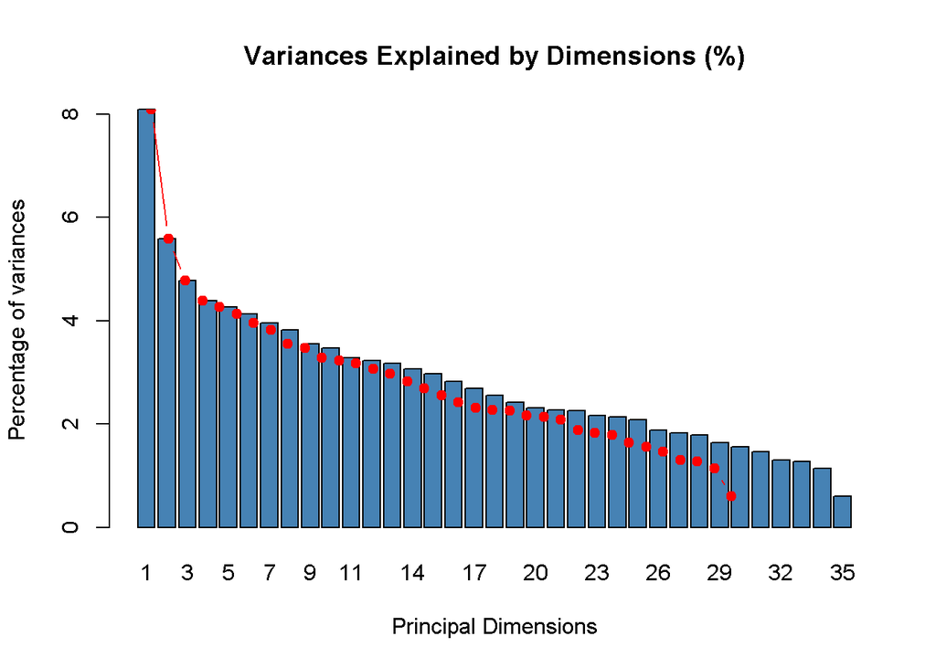

```r
eig.val <- res_mca$eig
barplot(eig.val[, 2],
        names.arg = 1:nrow(eig.val),
        main = "Variances Explained by Dimensions (%)",
        xlab = "Principal Dimensions",
        ylab = "Percentage of variances",
        col ="steelblue")
# Add connected line segments to the plot
lines(x = 1:nrow(eig.val), eig.val[, 2],
      type = "b", pch = 19, col = "red")
```

Eigenvalues can be used to determine the number of axes to retain. There is no “rule of thumb” to choose the number of dimensions to keep for the data interpretation. It depends on the research question and the researcher’s need. For example, if you are satisfied with 80% of the total variances explained then use the number of dimensions necessary to achieve that.

The inertia of the first and second dimensions suggest the number of dimensions that should be studied. The first two express 14% of the total dataset variance meaning that 14% of the individuals or variables total variability is explained by the plane. This is disappointedly a very small percentage.

An estimation of the right number of axis to interpret suggests to focus on the first 10. These axis present an amount of inertia greater than those obtained by the 0.95-quantile of random distributions meaning that only the first 10 axis are carrying a real information.

The proportion of variances retained by the different dimensions (axes) can be extracted using the function get_eigenvalue() as follow:

```r
eig.val <- get_eigenvalue(res_mca)
head(eig.val,n=10)
```

```
##        eigenvalue variance.percent cumulative.variance.percent
## Dim.1       0.149              8.1                         8.1
## Dim.2       0.103              5.6                        13.7
## Dim.3       0.088              4.8                        18.5
## Dim.4       0.081              4.4                        22.8
## Dim.5       0.079              4.3                        27.1
## Dim.6       0.076              4.1                        31.2
## Dim.7       0.073              4.0                        35.2
## Dim.8       0.070              3.8                        39.0
## Dim.9       0.065              3.5                        42.6
## Dim.10      0.064              3.5                        46.1
```

##### Description of the first plane

To further clarify the MCA results graphical representation is used. Firstly, there is biplot showing the global pattern within the data. Observations are represented by blue points and variables by red triangles and labels. The distance between any observation points or variable points gives a measure of their similarity (or dissimilarity). Similar types of individuals are close on the map, as well as similar kinds of variables. The function fviz_mca_biplot() [factoextra package] is used to draw the biplot of individuals and variable categories:

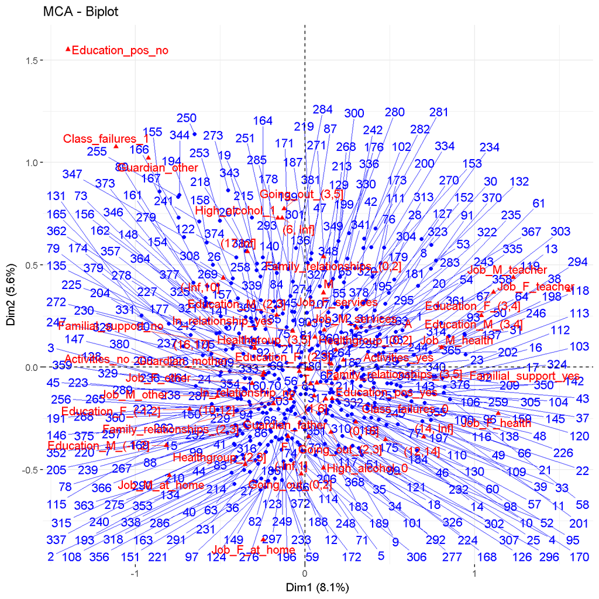

```r
fviz_mca_biplot(res_mca,
               repel = TRUE, # Avoid text overlapping (slow if many point)
               ggtheme = theme_minimal())
```

##### Biplots

Next, a plot is created to visualize the correlation between variables and MCA principal dimensions:

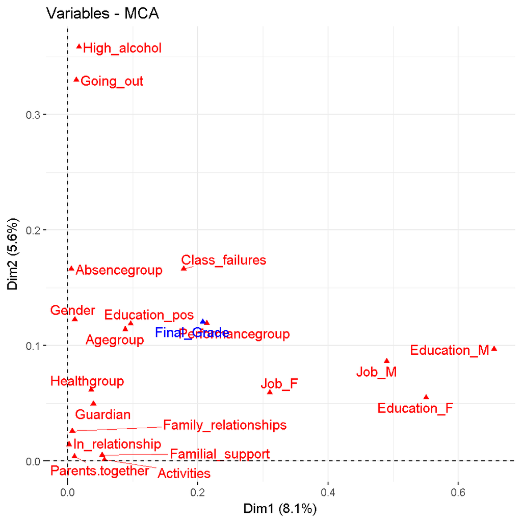

```r
fviz_mca_var(res_mca, choice = "mca.cor",
            repel = TRUE, # Avoid text overlapping (slow)
            ggtheme = theme_minimal())
```

The plot should help to identify variables that are the most correlated with each dimension. The squared correlations between variables and the dimensions are used as coordinates.

The function get_mca_var() [in factoextra] is used to extract the results for variable categories. This function returns a list containing the coordinates, the cos2 and the contribution of variable categories:

var$coord: coordinates of variables to create a scatter plot var$cos2: represents the quality of the representation for variables on the factor map. var$contrib: contains the contributions (in percentage) of the variables to the definition of the dimensions.

```r
var <- get_mca_var(res_mca)
var
```

```
## Multiple Correspondence Analysis Results for variables
##  ===================================================
##   Name       Description
## 1 "$coord"   "Coordinates for categories"
## 2 "$cos2"    "Cos2 for categories"
## 3 "$contrib" "contributions of categories"
```

To visualize the correlation between variables and MCA principal dimensions, type this:

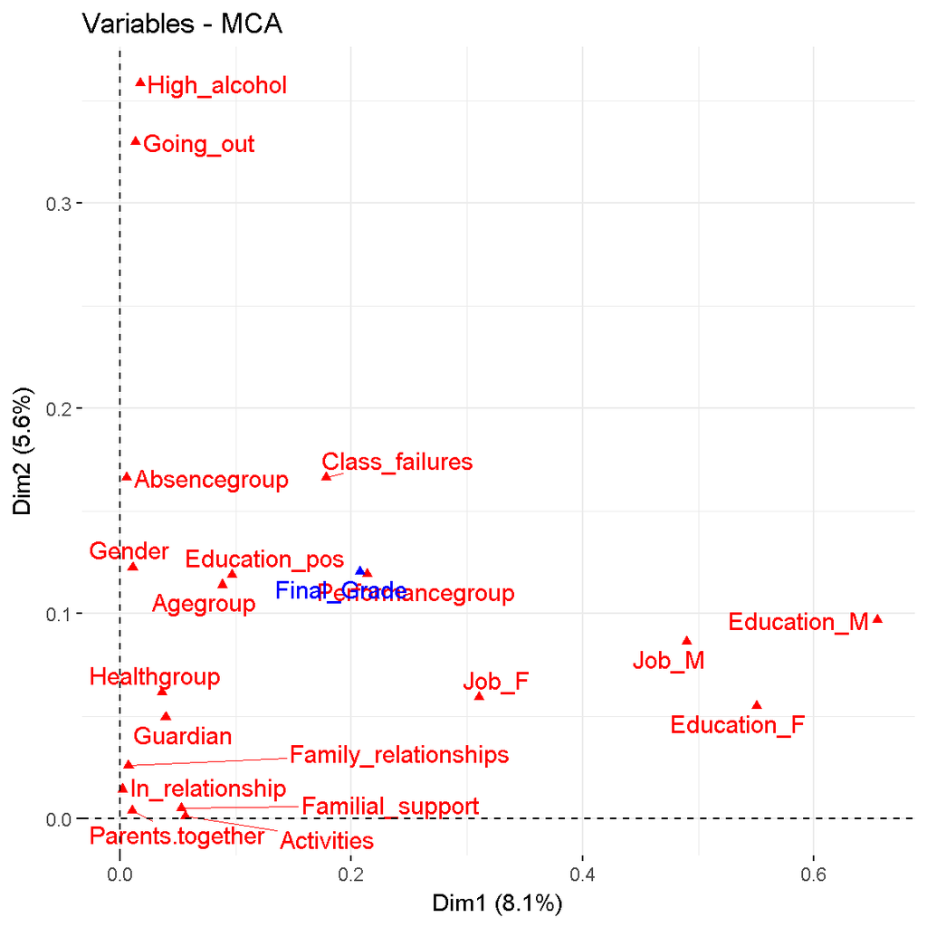

```r
fviz_mca_var(res.mca, choice = "mca.cor",
            repel = TRUE, # Avoid text overlapping (slow)
            ggtheme = theme_minimal())
```

The plot above helps to identify variables that are the most correlated with each dimension. The squared correlations between variables and the dimensions are used as coordinates.

Use the function fviz_mca_var() [in factoextra] to visualize only variable categories:

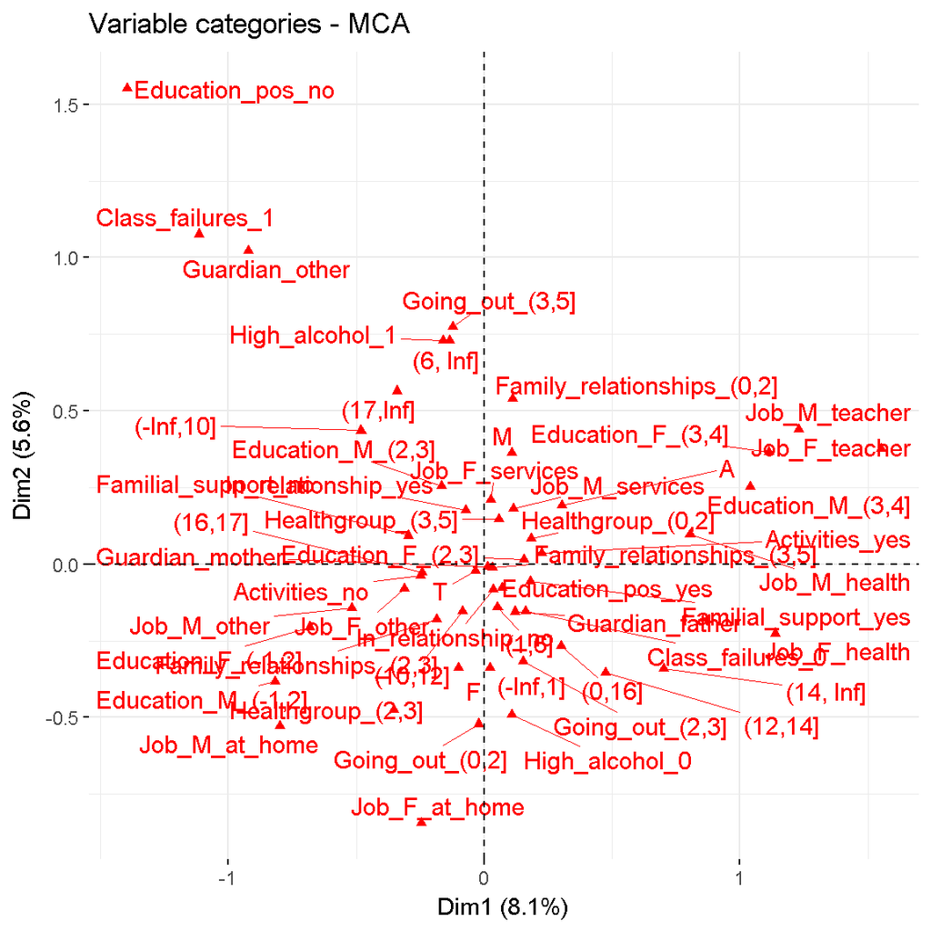

```r
fviz_mca_var(res_mca,
             repel = TRUE, # Avoid text overlapping (slow)
             ggtheme = theme_minimal())
```

It’s possible to change the color and the shape of the variable points using the arguments col.var and shape.var as follow:

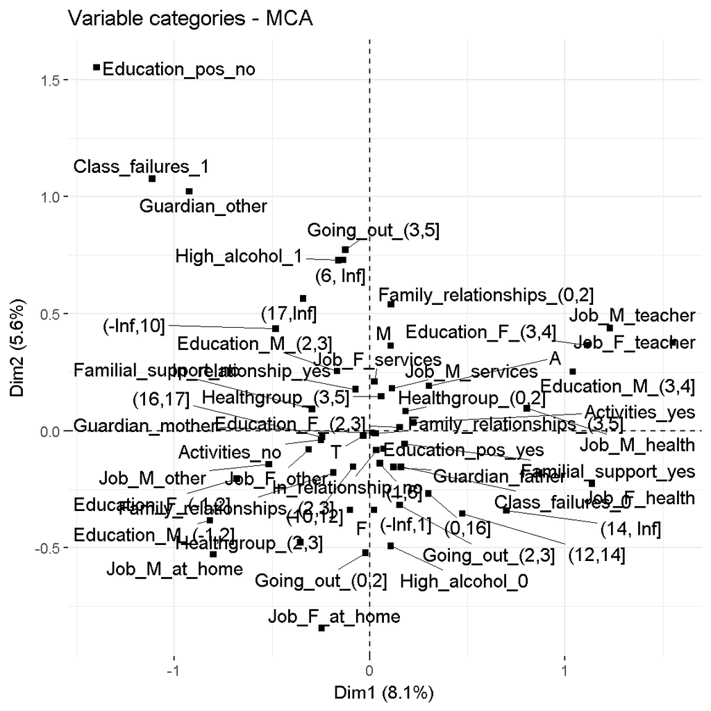

```r
fviz_mca_var(res_mca, col.var="black", shape.var = 15,
             repel = TRUE)
```

Variable categories with a similar profile are grouped together. Negatively correlated variable categories are positioned on opposite sides of the plot origin (opposed quadrants). The distance between category points and the origin measures the quality of the variable category on the factor map. Category points that are away from the origin are well represented on the factor map.

If a variable category is well represented by two dimensions, the sum of the cos2 is closed to one. For some of the row items, more than 2 dimensions are required to perfectly represent the data.

It’s possible to color variable categories by their cos2 values using the argument col.var = “cos2”. This produces a gradient colors, which can be customized using the argument gradient.cols. For instance, gradient.cols = c(“white”, “blue”, “red”) means that:

variable categories with low cos2 values will be colored in “white” variable categories with mid cos2 values will be colored in “blue” variable categories with high cos2 values will be colored in “red”

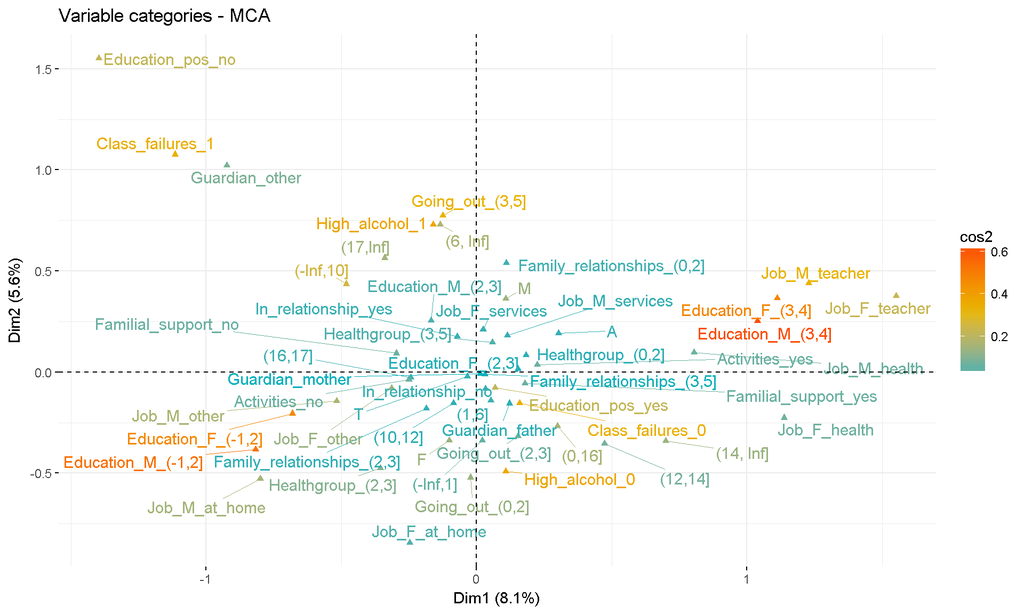

```r
# Color by cos2 values: quality on the factor map
fviz_mca_var(res_mca, col.var = "cos2",
             gradient.cols = c("#00AFBB", "#E7B800", "#FC4E07"),
             repel = TRUE, # Avoid text overlapping
             ggtheme = theme_minimal())
```

And finally, as is described in the exercise instructions: “The typical graphs show the original classes of the discrete variables on the same”map“, making it possible to reveal connections (correspondences) between different things that would be quite impossible to see from the corresponding cross tables (too many numbers!).”

Note that, it’s also possible to change the transparency of the variable categories according to their cos2 values using the option alpha.var = “cos2”. For example, type this:

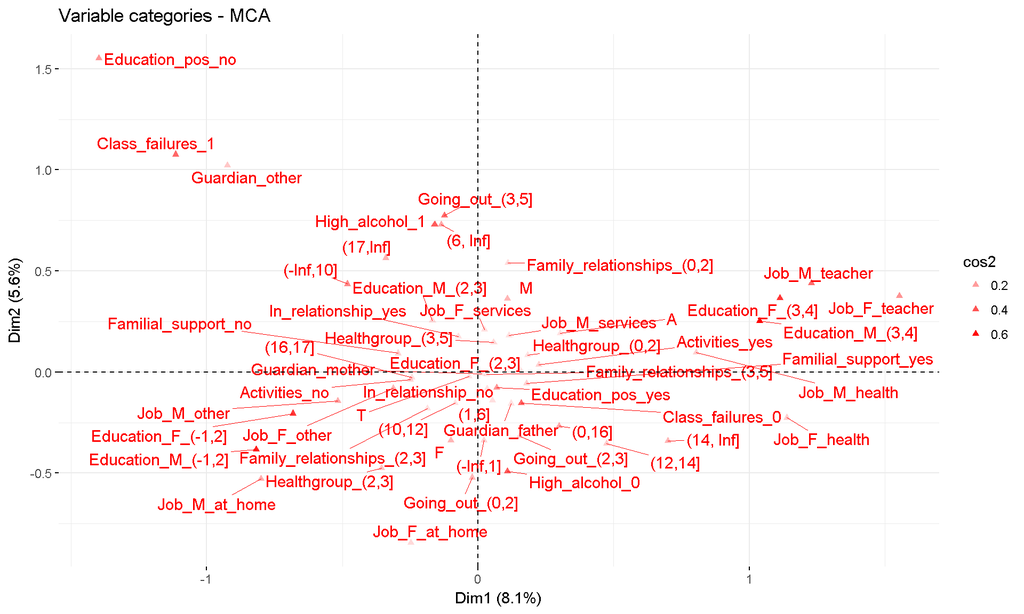

```r
# Change the transparency by cos2 values
fviz_mca_var(res_mca, alpha.var="cos2",
             repel = TRUE,
             ggtheme = theme_minimal(),selectMod="cos2 10")
```

You can visualize the cos2 of row categories on all the dimensions using the corrplot package:

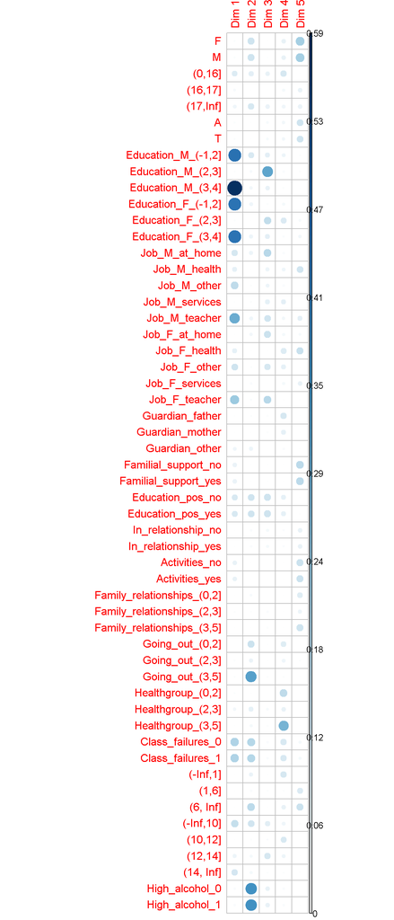

```r
library("corrplot")
corrplot(var$cos2, is.corr=FALSE)
```

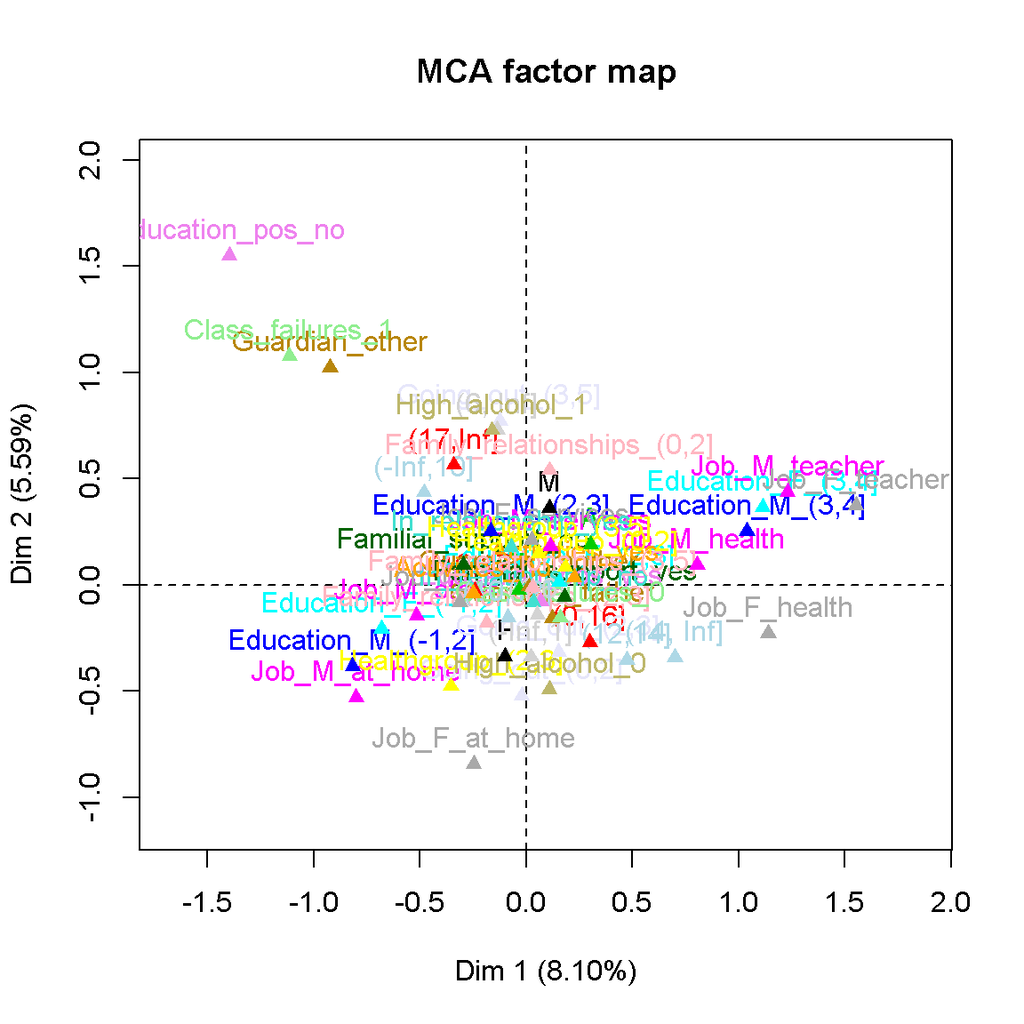

```r
plot(res_mca, invisible=c("ind"), habillage = "quali")
```

It’s also possible to create a bar plot of variable cos2 using the function fviz_cos2()[in factoextra]:

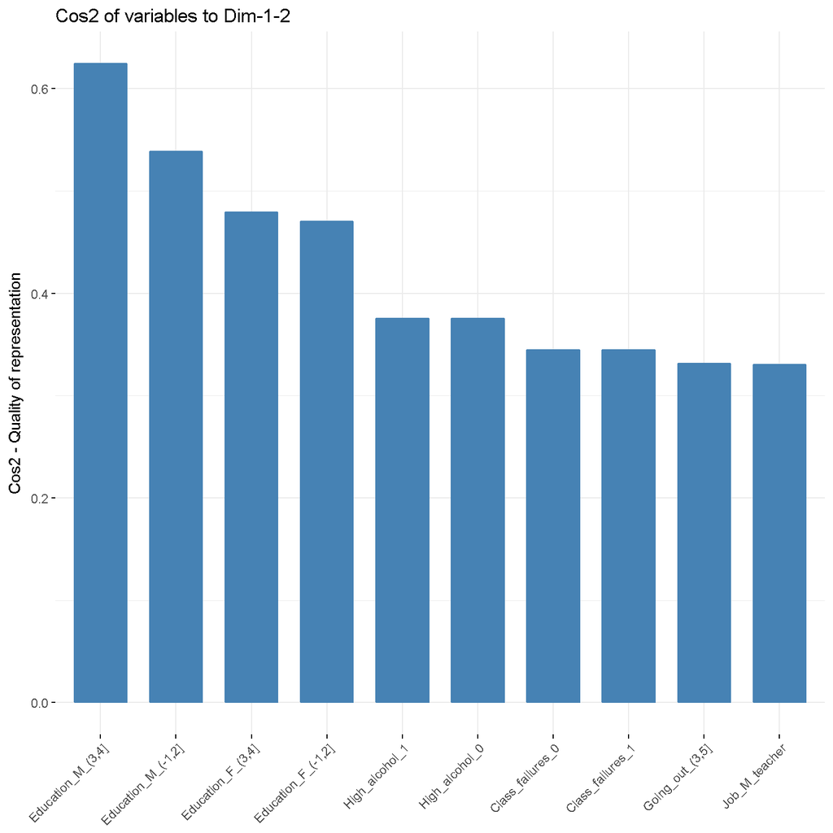

```r
# Cos2 of variable categories on Dim.1 and Dim.2
fviz_cos2(res_mca, n=10,choice = "var", axes = 1:2,top=10)
```

The function fviz_contrib() [factoextra package] can be used to draw a bar plot of the contribution of variable categories. The R code below shows the top 15 variable categories contributing to the dimensions:

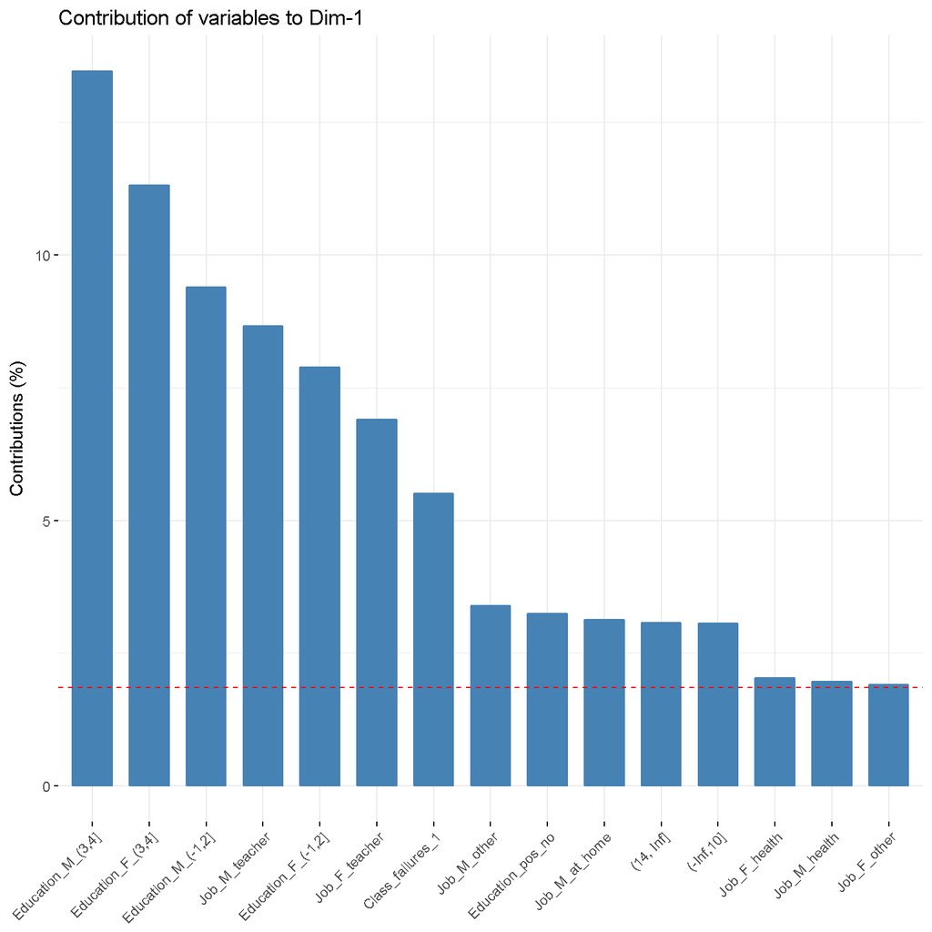

```r
# Contributions of rows to dimension 1
fviz_contrib(res_mca, choice = "var", axes = 1, top = 15)
```